# Class 2 Lab

Sequence Alignment & Database Searching (Pt. 1)

Author

Barry Grant

Published

December 15, 2025

**NoteInstructions**

This document is an alternative, accessible HTML version of the lab sheet. The primary version of this material is provided as a **PDF**, which is designed for in-class use, includes form fields for all questions, and is intended for direct submission to **GradeScope**.

The HTML version is optimized for screen readers and complies with the Web Content Accessibility Guidelines (WCAG 2.1). If you are able to do so, please use the PDF version.

## Learning Objectives

By the end of this lab, you will be able to:

1. **Explain** how dot plot parameters (window size, step size, and match stringency) affect the visualization of sequence similarity and the trade-off between sensitivity and specificity.
2. **Perform** pairwise sequence alignment by hand using the Needleman-Wunsch dynamic programming algorithm with specified scoring parameters.
3. **Interpret** the output of a completed scoring matrix to identify optimal alignments and recognize when multiple optimal solutions exist.
4. **Use** NCBI BLAST to search protein databases for homologous sequences, applying appropriate filters and database selections to refine results.
5. **Evaluate** BLAST results critically, considering E-values, percent identity, and query coverage to assess the biological significance of reported matches.

## Overview:

Aligning novel sequences with previously characterized genes or proteins provides important insights into their common attributes and evolutionary origins.

In sections 1, 2 and 3 of this hands-on session we will first explore the principles and methods underlying the computational comparison and alignment of biomolecular sequences.

In section 4 we explore how these methods are used to search databases to identify homologues sequences (i.e. finding evolutionary related genes or proteins that are descended from a common ancestor).

In section 5 we highlight the detection limits of conventional BLAST. This sets the scene for introducing more sensitive (but often more time consuming) approaches including Profiles, PSI-BLAST and Hidden Markov Models (HMMs).

## Section 1: Dot Plot Parameters

Dot plots are a simple graphical approach for the visual comparison of two sequences. They have a long history (see [Maizel and Lenk 1981](https://pubmed.ncbi.nlm.nih.gov/6801656/) and references therein) and entail placing one sequence on the vertical axis of a 2D grid (or matrix) and the other on the horizontal.

In its simplest form, a dot is placed where the horizontal and vertical sequence values match. More elaborate forms use *‘sliding windows’* composed of multiple characters and a threshold value, or *‘match stringency’* for two windows to be considered as matched.

Visit our very own simple dot plot web-app ([Link1](https://barryus.shinyapps.io/dotplot/) or it’s mirror [Link2](https://bioboot.shinyapps.io/dotplot/)) and get a feel for how altering these major dot plot parameters change the displayed protein and DNA dot plots.

> N.B. Note the questions listed on the web page (also found below) and add your answers in the space provided on the next page.

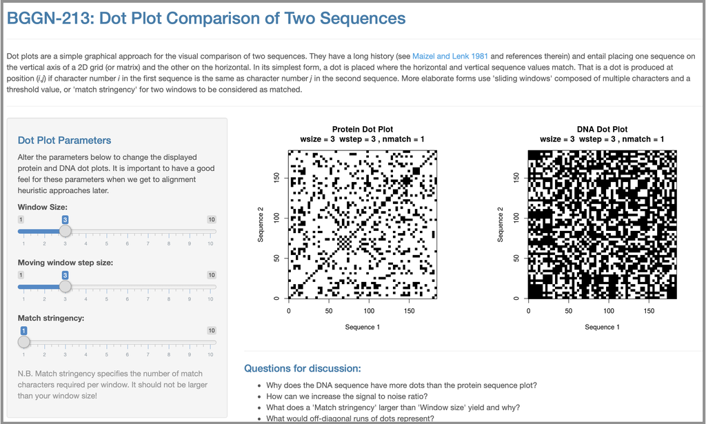

Figure 1: Interactive dot plot web app to explore fundamental concepts of biomolecular sequence comparison

**Q1** Why does the DNA sequence have more dots than the protein sequence plot?

**Tip**

What do you know about DNA composition vs protein composition?

**Q2** How can we increase the signal to noise ratio?

**Tip**

Signal in this case means correct matches that we actually want to highlight and noise means spurious matches that we don’t want.

**Q3** What does a ‘Match stringency’ larger than ‘Window size’ yield and why?

**Q4** What are the major weaknesses of this approach?

**Tip**

Is your inner nerd happy with this approach? How would you use it to determine if a second set of sequences was more similar to each other than a first set of sequences?

## Section 2: Needleman-Wunsch Alignment

Sequence alignment methods often use something called a ‘dynamic programming’ algorithm that can be usefully considered as an extension of the dot plot approach. Here we have two sample sequences, and we’d like to use the Needleman-Wunsch algorithm discussed in class to align them. Feel free to use the classroom white-boards and/or pen and paper and attach a photo to this PDF for gradescope.

Sequence 1: ATTGC  
Sequence 2: AGTTC

**Tip**

It can be hard to store the all important progress arrows in the PDF version of this document and thus you may prefer to use your own paper (or white-board) version that you can take a photo off for upload to gradescope.

Optimal Score:  
Alignments:

## Section 3: Practice makes perfect

Again use the Needleman-Wunsch algorithm discussed in class to align the following sequences:

Sequence 1: TATAG  
Sequence 2: GTTAC

Optimal Score:  
Alignments:

## Section 4: Finding homologous sequence

Your collaborators found a protein while working on a fly species and have asked you to see if there are any human homologs.

```
>fly_protein
MDNHSSVPWASAASVTCLSLDAKCHSSSSSSSSKSAASSISAIPQEETQTMRHIAHTQRCLSRLTSLVAL
LLIVLPMVFSPAHSCGPGRGLGRHRARNLYPLVLKQTIPNLSEYTNSASGPLEGVIRRDSPKFKDLVPNY
NRDILFRDEEGTGADRLMSKRCKEKLNVLAYSVMNEWPGIRLLVTESWDEDYHHGQESLHYEGRAVTIAT
SDRDQSKYGMLARLAVEAGFDWVSYVSRRHIYCSVKSDSSISSHVHGCFTPESTALLESGVRKPLGELSI
GDRVLSMTANGQAVYSEVILFMDRNLEQMQNFVQLHTDGGAVLTVTPAHLVSVWQPESQKLTFVFADRIE
EKNQVLVRDVETGELRPQRVVKVGSVRSKGVVAPLTREGTIVVNSVAASCYAVINSQSLAHWGLAPMRLL
STLEAWLPAKEQLHSSPKVVSSAQQQNGIHWYANALYKVKDYVLPQSWRHD
```

**Q7** Using the default settings for NCBI BLAST, can you find any homologs for this protein in Humans?

**Tip**

Try using the LIMITS and FILTERING options we covered in the last lab.

**Q8** Try changing the database to *refseq_protein*. From the results, select a few proteins and find the common name for the species. What trend do you notice as you move down the results list?

**Tip**

Search google for the species name and use the taxonomy tab on your NCBI BLAST results page.

**Q9** Finally, try also limiting the search to only *H. Sapiens*. What function do these proteins have?

**Tip**

You can simply type the *Taxon ID* **9606** in the “Organism” box.

**Q10** What function do you think this protein performs for your collaborators’ organism?

## OPTIONAL EXTENSION

We will revisit this problem and introduce approaches with greater sensitivity (i.e. ability to find more remote homologues) in the next lab.

## Section 5: The limits of using BLAST for remote homologue detection

Let’s return to the HBB protein that we explored in a previous class and see if we can find distantly related myoglobin and neuroglobin using HBB as a BLAST query.

```
>gi|4504349|ref|NP_000509.1| hemoglobin subunit beta [Homo sapiens]
MVHLTPEEKSAVTALWGKVNVDEVGGEALGRLLVVYPWTQRFFESFGDLSTPDAVMGNPKVKAHGKKVLG
AFSDGLAHLDNLKGTFATLSELHCDKLHVDPENFRLLGNVLVCVLAHHFGKEFTPPVQAAYQKVVAGVAN
ALAHKYH
```

After selecting **blastp** and entering the sequence, be sure to change the search database to “**refseq-protein**” and restrict our search organism to only **humans** (taxid: 9606). This will help focus our results to highlight distant homologs in humans.

**Q11** What homologs did you find with this simple blastp search? Note their percent identities, coverage and E-values.

Now we could try changing the **Algorithm parameters** on the submission page to increase the number of hits reported. To do this you can click on the **Edit and Resubmit** link at the top left of your results page.

**Q12** Try increasing the Expect threshold for your blasts search (e.g. to 2000). What new hits were reported? What about their alignment statistics? Do you trust these matches? Did you find myoglobin?

**Q13**: What one part of this exercise or associated lecture material is still confusing?

If appropriate please also indicate the question number from this document and answer the question in the following anonymous form: [**Muddy_Point_Assesment_Form**](https://forms.gle/XFgux3J6pU34Qeen6)

Your comments will let us know which material needs to be further clarified and will help us gain stronger control of the material in this course. Thank you!

## Discussion

Many useful ‘rules of thumb’ are expressed in terms of percent identity. If two proteins have more than 45% identical residues in their optimal alignment they typically have very similar structures and are likely to have a similar function. If two proteins have more than 25% identical residues (but less than 45% identity), they are likely to have a similar general folding pattern. Note that we will expand on the basis of this important *sequence > structure > function* relationship in the next lab where we also explore the detection limits of standard BLAST searches for identifying remote homologs.

Observations of a lower degree of sequence similarity cannot however rule out homology. Our very own late [Russ Doolittle](https://en.wikipedia.org/wiki/Russell_Doolittle) defined the region between 18-25% sequence identity as the “twilight zone” in which the suggestion of homology is tantalizing but dangerous. Below the **twilight zone** is a region where pairwise sequence alignments tell us very little - sometimes called the “midnight zone”.

Our next class will introduce more advanced topics including profile and structure based approaches that can delve deeper into these important, but often hard to detect, sequence-structure-function relationships.